# diabete_prediction

**Made By DAHOU RENAUD L. Data Scientist in Benin**

- Whatsapp: +22967927952
- Email: dahou.r@yahoo.com

[figure not shown]

### Le contexte

Cet ensemble de données ([lien](https://www.kaggle.com/uciml/pima-indians-diabetes-database)) provient à l'origine de l'Institut national du diabète et des maladies digestives et rénales. L'objectif de l'ensemble de données est de prédire de manière diagnostique si un patient souffre ou non de diabète, sur la base de certaines mesures diagnostiques incluses dans l'ensemble de données. Plusieurs contraintes ont été placées sur la sélection de ces instances à partir d'une base de données plus importante. En particulier, tous les patients ici sont des femmes d'au moins 21 ans d'origine indienne Pima.

Contenu Les ensembles de données se compose de plusieurs variables prédictives médical et une variable cible, Outcome. Les variables prédictives incluent le nombre de grossesses que la patiente a eues, son IMC, son niveau d'insuline, son âge, etc.

### Connexion à notre répertoire

```python
from google.colab import drive
drive.mount('/content/drive/')
```

[output not shown]

```python
import os
os.chdir("/content/drive/My Drive/DATASCIENCE/Projet/diabete_prediction")
```

```python
#!jupyter nbconvert --to html diabete_prediction.ipynb
```

[output not shown]

```python
# Added version check for recent scikit-learn 0.18 checks
from distutils.version import LooseVersion as Version
from sklearn import __version__ as sklearn_version
```

# 1. Importation des bibliothèques

```python
import pandas
import numpy as np
import matplotlib.pyplot as plt
from matplotlib import rcParams
from pandas.plotting import scatter_matrix
from sklearn.model_selection import train_test_split
import sklearn.metrics as metrics
from sklearn.metrics import classification_report
from sklearn.metrics import confusion_matrix
from sklearn.metrics import accuracy_score
from sklearn.pipeline import Pipeline
from sklearn.model_selection import GridSearchCV
from sklearn.model_selection import StratifiedKFold
#Importing most common alogorithms
from sklearn.linear_model import LogisticRegression
from sklearn.neural_network import MLPClassifier
from sklearn.neighbors import KNeighborsClassifier
from sklearn.svm import SVC#we will not be using SVM due tot he huge training time required on our dataset.
from sklearn.gaussian_process import GaussianProcessClassifier
from sklearn.multiclass import OneVsRestClassifier
from sklearn.gaussian_process.kernels import RBF
from sklearn.tree import DecisionTreeClassifier
from sklearn.ensemble import RandomForestClassifier, AdaBoostClassifier
from sklearn.naive_bayes import GaussianNB
from sklearn.discriminant_analysis import QuadraticDiscriminantAnalysis,LinearDiscriminantAnalysis
from sklearn import model_selection #Cross-validation multiple scoring function
import warnings
warnings.simplefilter("ignore")
```

# 2. Chargement de la base de donnée

```python
#load dataset
import pandas as pd
import warnings
warnings.filterwarnings('ignore')
path= "/content/drive/My Drive/DATASCIENCE/Projet/diabete_prediction//pima-indians-diabetes.data"
col_names = ['pregnant', 'glucose', 'bp', 'skin', 'insulin', 'bmi', 'pedigree', 'age', 'label']
df = pd.read_csv(path, header=None, names=col_names)
```

# 3. Analyse des données

## Statistiques descriptives

```python
print ('Descriptive Statistics' + str(df.describe()))
print ('Dataset Dimensions ' + str(df.shape)) # 768 rows, 9 attributes including class
```

```
Descriptive Statistics       pregnant  glucose       bp     skin  ...      bmi  pedigree      age    label
count   768.000  768.000  768.000  768.000  ...  768.000   768.000  768.000  768.000
mean      3.845  120.895   69.105   20.536  ...   31.993     0.472   33.241    0.349
std       3.370   31.973   19.356   15.952  ...    7.884     0.331   11.760    0.477
min       0.000    0.000    0.000    0.000  ...    0.000     0.078   21.000    0.000
25%       1.000   99.000   62.000    0.000  ...   27.300     0.244   24.000    0.000
50%       3.000  117.000   72.000   23.000  ...   32.000     0.372   29.000    0.000
75%       6.000  140.250   80.000   32.000  ...   36.600     0.626   41.000    1.000
max      17.000  199.000  122.000   99.000  ...   67.100     2.420   81.000    1.000

[8 rows x 9 columns]
Dataset Dimensions (768, 9)
```

nous pouvons constater que la population étudier à un age compris entre 21 ans et 81ans

## Types de données de colonne

```python
pandas.set_option('display.max_rows', 500)
print ('Data Types of each Attribute\n' + str(df.dtypes))
```

```
Data Types of each Attribute
pregnant      int64
glucose       int64
bp            int64
skin          int64
insulin       int64
bmi         float64
pedigree    float64
age           int64
label         int64
dtype: object
```

## Aperçu des 20 premières lignes de données

```python
pandas.set_option('display.width', 100)
print ('First 20 rows of data\n' + str(df.head(20)))
```

```
First 20 rows of data
    pregnant  glucose  bp  skin  insulin   bmi  pedigree  age  label
0          6      148  72    35        0  33.6     0.627   50      1
1          1       85  66    29        0  26.6     0.351   31      0
2          8      183  64     0        0  23.3     0.672   32      1
3          1       89  66    23       94  28.1     0.167   21      0
4          0      137  40    35      168  43.1     2.288   33      1
5          5      116  74     0        0  25.6     0.201   30      0
6          3       78  50    32       88  31.0     0.248   26      1
7         10      115   0     0        0  35.3     0.134   29      0
8          2      197  70    45      543  30.5     0.158   53      1
9          8      125  96     0        0   0.0     0.232   54      1
10         4      110  92     0        0  37.6     0.191   30      0
11        10      168  74     0        0  38.0     0.537   34      1
12        10      139  80     0        0  27.1     1.441   57      0
13         1      189  60    23      846  30.1     0.398   59      1
14         5      166  72    19      175  25.8     0.587   51      1
15         7      100   0     0        0  30.0     0.484   32      1
16         0      118  84    47      230  45.8     0.551   31      1
17         7      107  74     0        0  29.6     0.254   31      1
18         1      103  30    38       83  43.3     0.183   33      0
19         1      115  70    30       96  34.6     0.529   32      1
```

## Résumez la distribution de chaque attribut(colonne)

```python
pandas.set_option('precision', 3)
print ('Distribution of each Attribute\n' + str(df.describe()))
```

```
Distribution of each Attribute
       pregnant  glucose       bp     skin  ...      bmi  pedigree      age    label
count   768.000  768.000  768.000  768.000  ...  768.000   768.000  768.000  768.000
mean      3.845  120.895   69.105   20.536  ...   31.993     0.472   33.241    0.349
std       3.370   31.973   19.356   15.952  ...    7.884     0.331   11.760    0.477
min       0.000    0.000    0.000    0.000  ...    0.000     0.078   21.000    0.000
25%       1.000   99.000   62.000    0.000  ...   27.300     0.244   24.000    0.000
50%       3.000  117.000   72.000   23.000  ...   32.000     0.372   29.000    0.000
75%       6.000  140.250   80.000   32.000  ...   36.600     0.626   41.000    1.000
max      17.000  199.000  122.000   99.000  ...   67.100     2.420   81.000    1.000

[8 rows x 9 columns]
```

## Distribution de la cible

```python
print ('Class Distribution\n' + str(df.groupby('label').size()))
```

```
Class Distribution
label
0    500
1    268
dtype: int64
```

Nous avons 500 patients sains et- 268 souffrant du diabète

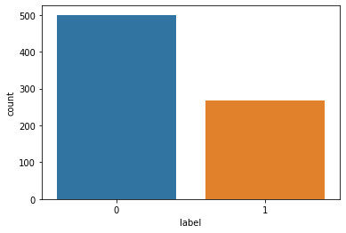

```python
import seaborn as sns
sns.countplot(x="label", data=df)
```

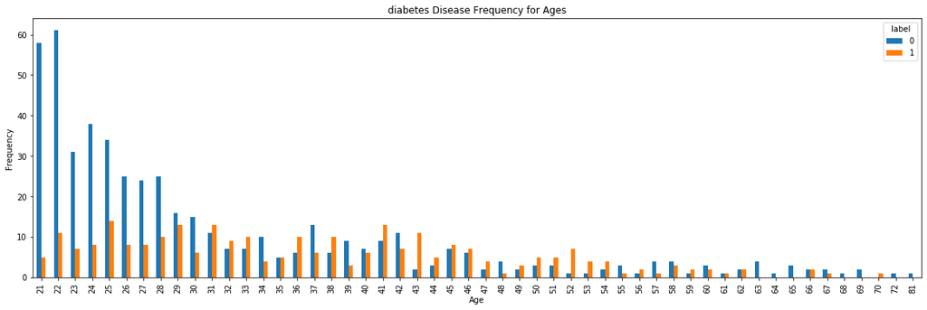

```python
import matplotlib.pyplot as plt

pd.crosstab(df.age,df['label']).plot(kind="bar",figsize=(20,6))
plt.title('diabetes Disease Frequency for Ages')
plt.xlabel('Age')
plt.ylabel('Frequency')
plt.savefig('diabetesDiseaseAndAges.png')
plt.show()
```

Créons un intervalle d'âge pour voir les tranches qui sont les plus risquées pour contracter une maladie de diabète

```python
df['ageint']=pd.cut(df.age, bins=[ 20, 40, 60, 80, 100 ], labels=['A', 'B', 'C', 'D'])
df
```

|  | pregnant | glucose | bp | skin | insulin | bmi | pedigree | age | label | ageint |
| --- | --- | --- | --- | --- | --- | --- | --- | --- | --- | --- |
| 0 | 6 | 148 | 72 | 35 | 0 | 33.6 | 0.627 | 50 | 1 | B |
| 1 | 1 | 85 | 66 | 29 | 0 | 26.6 | 0.351 | 31 | 0 | A |
| 2 | 8 | 183 | 64 | 0 | 0 | 23.3 | 0.672 | 32 | 1 | A |
| 3 | 1 | 89 | 66 | 23 | 94 | 28.1 | 0.167 | 21 | 0 | A |
| 4 | 0 | 137 | 40 | 35 | 168 | 43.1 | 2.288 | 33 | 1 | A |
| ... | ... | ... | ... | ... | ... | ... | ... | ... | ... | ... |
| 763 | 10 | 101 | 76 | 48 | 180 | 32.9 | 0.171 | 63 | 0 | C |
| 764 | 2 | 122 | 70 | 27 | 0 | 36.8 | 0.340 | 27 | 0 | A |
| 765 | 5 | 121 | 72 | 23 | 112 | 26.2 | 0.245 | 30 | 0 | A |
| 766 | 1 | 126 | 60 | 0 | 0 | 30.1 | 0.349 | 47 | 1 | B |
| 767 | 1 | 93 | 70 | 31 | 0 | 30.4 | 0.315 | 23 | 0 | A |

768 rows × 10 columns

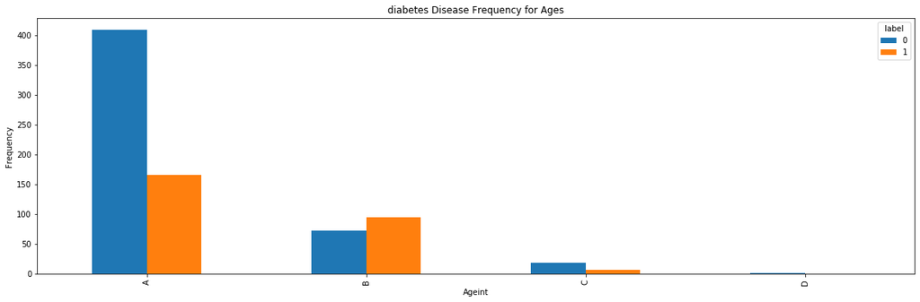

```python
pd.crosstab(df.ageint,df['label']).plot(kind="bar",figsize=(20,6))
plt.title('diabetes Disease Frequency for Ages')
plt.xlabel('Ageint')
plt.ylabel('Frequency')
plt.savefig('diabetesDiseaseAndAges.png')
plt.show()
```

Nous pouvons constater que les sous-populations les plus malade sont les personnes dont l'âge se situe entre [20-40[ en premier et [40-60[ en second. Tandis que celle entre [60-80[ et celle entre [80-100] sont les moins malades ou pas

**La question qu'on peut se poser est qu'est-ce qu'il existe réellement un lien fort entre l'âge et la maladie de diabete développé?** L'analyse de corrélation nous en dira plus

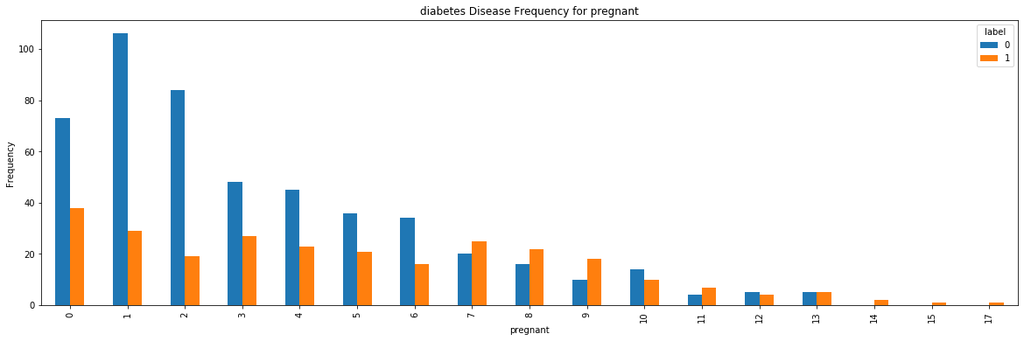

```python
pd.crosstab(df.pregnant,df['label']).plot(kind="bar",figsize=(20,6))
plt.title('diabetes Disease Frequency for pregnant')
plt.xlabel('pregnant')
plt.ylabel('Frequency')
plt.savefig('diabetesDiseaseAndpregnants.png')
plt.show()
```

La question qu'on peut se poser est qu'est-ce qu'il existe réellement un lien fort entre nombre de grossesses et la maladie de diabete développé? L'analyse de corrélation nous en dira plus

## Visualisations et correlation

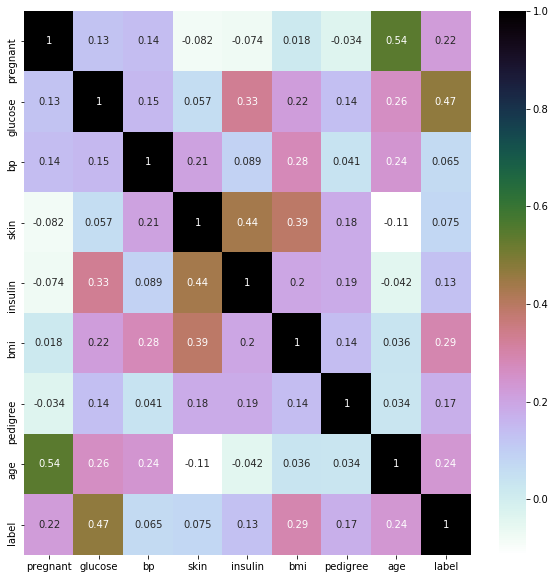

```python
#corrélation
import seaborn as sns
plt.figure(figsize=(10,10))
sns.heatmap(df.corr(),annot=True,cmap='cubehelix_r')
plt.show();
```

On note une corrélation généralement moyenne avec la cible ça serait maldroit de sélectionner des variables explicatives dans ces conditions. Alors nous optons à une réduction de dimension. Mais d'abord répondons à nos questions ci-dessus la corrélation de la cible avec l'âge et le noombre de grossesse sont-elle-le fruit du hasard?

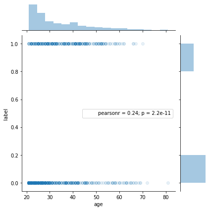

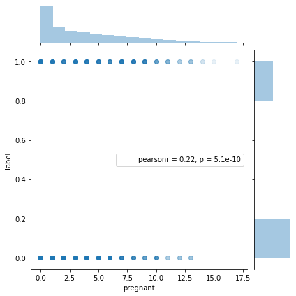

```python
from scipy.stats import pearsonr
sns.jointplot(x='age', y='label', data=df, alpha = 0.1, stat_func=pearsonr)
sns.jointplot(x='pregnant', y='label', data=df, alpha = 0.1, stat_func=pearsonr)
```

Nous obtenons un p inférieur à 0,05 au niveaus de les variables ('âge", pregnant) cela montre qu'il existe bel et bien un lien entre elles et la cible

## **Division des données en train et test**

```python
X=df[['pregnant', 'glucose', 'bp', 'skin', 'insulin', 'bmi', 'pedigree', 'age']].values
y=df[['label']].values
```

```python
X_train, X_test, y_train, y_test = \
    train_test_split(X, y, test_size=0.20, random_state=1)
```

## **Mise à echelle**

```python
from sklearn.preprocessing import MinMaxScaler
mms = MinMaxScaler()

X_train_std = mms.fit_transform(X_train)
X_test_std = mms.transform(X_test)
```

## **Combinaison de plusieurs Algorithme**

```python
seed = 42
np.random.seed(seed)
# prepare models
models = []
models.append(('LR', LogisticRegression(multi_class='auto',n_jobs=-1)))
models.append(('LDA', LinearDiscriminantAnalysis()))
models.append(('QDA',QuadraticDiscriminantAnalysis()))
models.append(('KNN', KNeighborsClassifier(7, n_jobs=-1)))
models.append(('CART', DecisionTreeClassifier(max_depth=10)))
models.append(('NB', GaussianNB()))
models.append(('Gaussian Process Classifier', GaussianProcessClassifier()))
models.append(('SVM_linear', SVC(kernel="linear", C=0.025)))#we will not be using SVM due to the huge training time required for this dataset
models.append(('SVM_',SVC(gamma=2, C=1)))
models.append(('RandomForest',RandomForestClassifier( n_estimators=100, n_jobs=-1)))
models.append(('MLP',MLPClassifier(alpha=0.0001)))
models.append(('ADABoost',AdaBoostClassifier()))
models.append(('One-Vs-Rest LR', OneVsRestClassifier(LogisticRegression(multi_class='auto',n_jobs=-1),n_jobs=-1)))
models.append(('One-Vs-Rest LDA', OneVsRestClassifier(OneVsRestClassifier(LinearDiscriminantAnalysis(),n_jobs=-1))))
models.append(('One-Vs-Rest QDA',OneVsRestClassifier(QuadraticDiscriminantAnalysis())))
models.append(('One-Vs-Rest KNN', OneVsRestClassifier(KNeighborsClassifier(7, n_jobs=-1))))
models.append(('One-Vs-Rest CART', OneVsRestClassifier(DecisionTreeClassifier(max_depth=10),n_jobs=-1)))
models.append(('One-Vs-Rest NB', OneVsRestClassifier(GaussianNB(),n_jobs=-1)))
models.append(('One-Vs-Rest Gaussian Process Classifier', OneVsRestClassifier(GaussianProcessClassifier(),n_jobs=-1)))
models.append(('One-Vs-Rest SVM_linear', SVC(kernel="linear", C=0.025)))#we will not be using SVM due to the huge training time required for this dataset
models.append(('One-Vs-Rest SVM_',SVC(gamma=2, C=1)))
models.append(('One-Vs-Rest RandomForest',OneVsRestClassifier(RandomForestClassifier( n_estimators=100, n_jobs=-1),n_jobs=-1)))
models.append(('One-Vs-Rest MLP',OneVsRestClassifier(MLPClassifier(alpha=0.0001),n_jobs=-1)))
models.append(('One-Vs-Rest ADABoost',OneVsRestClassifier(AdaBoostClassifier(),n_jobs=-1)))

# evaluate each model in turn

results = []
scoring = ['accuracy',
          'precision_weighted',
          'recall_weighted',
          'f1_weighted']
names = []

sk = model_selection.StratifiedKFold(n_splits=10, random_state=42)
for name, model in models:
    cv_results = model_selection.cross_validate(model, X_train_std, y_train, cv=sk, scoring=scoring)
    results.append(cv_results)
    names.append(name)
    msg ='-------------------------------------------------------------------------------------------------------------\n'
    msg = "Model : %s \n" % (name)
    msg = msg +'\n'
    msg =  msg + "Accuracy :  %f (%f)\n" % (cv_results['test_accuracy'].mean(),cv_results['test_accuracy'].std())
    msg =  msg + "Precision score :  %f (%f)\n" % (cv_results['test_precision_weighted'].mean(),cv_results['test_precision_weighted'].std())
    msg =  msg + "Recall score :  %f (%f)\n" % (cv_results['test_recall_weighted'].mean(),cv_results['test_recall_weighted'].std())
    msg =  msg + "F1 score :  %f (%f)\n" % (cv_results['test_f1_weighted'].mean(),cv_results['test_f1_weighted'].std())
    msg = msg + '------------------------------------------------------------------------------------------------------------\n'
    print(msg)
```

```
Model : LR

Accuracy :  0.758937 (0.051307)
Precision score :  0.753730 (0.056811)
Recall score :  0.758937 (0.051307)
F1 score :  0.743080 (0.059374)
------------------------------------------------------------------------------------------------------------

Model : LDA

Accuracy :  0.771999 (0.050222)
Precision score :  0.767541 (0.054000)
Recall score :  0.771999 (0.050222)
F1 score :  0.763067 (0.055578)
------------------------------------------------------------------------------------------------------------

Model : QDA

Accuracy :  0.736330 (0.068969)
Precision score :  0.729851 (0.079298)
Recall score :  0.736330 (0.068969)
F1 score :  0.729134 (0.075145)
------------------------------------------------------------------------------------------------------------

Model : KNN

Accuracy :  0.719910 (0.066950)
Precision score :  0.711853 (0.072491)
Recall score :  0.719910 (0.066950)
F1 score :  0.712592 (0.069313)
------------------------------------------------------------------------------------------------------------

Model : CART

Accuracy :  0.698678 (0.059790)
Precision score :  0.701669 (0.058641)
Recall score :  0.698678 (0.059790)
F1 score :  0.697840 (0.057466)
------------------------------------------------------------------------------------------------------------

```

[output cut: 136 more lines]

```
Model : One-Vs-Rest MLP

Accuracy :  0.758964 (0.054834)
Precision score :  0.752177 (0.060839)
Recall score :  0.758964 (0.054834)
F1 score :  0.748327 (0.061290)
------------------------------------------------------------------------------------------------------------

Model : One-Vs-Rest ADABoost

Accuracy :  0.734585 (0.059789)
Precision score :  0.729694 (0.063308)
Recall score :  0.734585 (0.059789)
F1 score :  0.730036 (0.062301)
------------------------------------------------------------------------------------------------------------
```

LinearDiscriminantAnalysis()(LDA) et GaussianProcessClassifier()(GC) on les meilleures performances. je vais utilisé les deux algoritghmes pour ce projet LDA pour la reduction de dimension et GC comme classifieur

```python
from sklearn.preprocessing import MinMaxScaler

pipe_lr = Pipeline([('scl', MinMaxScaler()),
                    ('reduce_dim', LinearDiscriminantAnalysis()),
                    ('clf', GaussianProcessClassifier())])

pipe_lr.fit(X_train, y_train)
print('Test Accuracy: %.3f' % pipe_lr.score(X_test, y_test))
y_pred = pipe_lr.predict(X_test)
```

```
Test Accuracy: 0.773
```